# Spruce needles season specificity analysis

Nicolas Delhomme, Thomas Riquelme

2017-07-31

# 1 Setup

Environment Set the working dir

```r
setwd("/mnt/picea/projects/spruce/sjansson/seasonal-needles/u2015030/")
```

Libraries

```r
suppressPackageStartupMessages(library(pander))
suppressPackageStartupMessages(library(RColorBrewer))
suppressPackageStartupMessages(library(VennDiagram))
suppressPackageStartupMessages(library(dendextend))
```

Sources

```r
source("~/Git/UPSCb/src/R/expressionSpecificityUtility.R")
source("~/Git/UPSCb/src/R/plot.multidensity.R")
```

Plotting param

```r
mar <- par("mar")
pal <- brewer.pal(8,"Dark2")
```

Read data

```r
load(file = "vst_aware_filtered.rda")
```

# 2 Prepare data

Replace sample id by sample dates

Aim: to recognize the dates and the seasons for clustering

```r
stopifnot(all(colnames(vst_aware_filtered) == names(ordered_dates)))
colnames(vst_aware_filtered) <- ordered_dates
```

# 3 Clustering

Based on the distance of counts data between samples

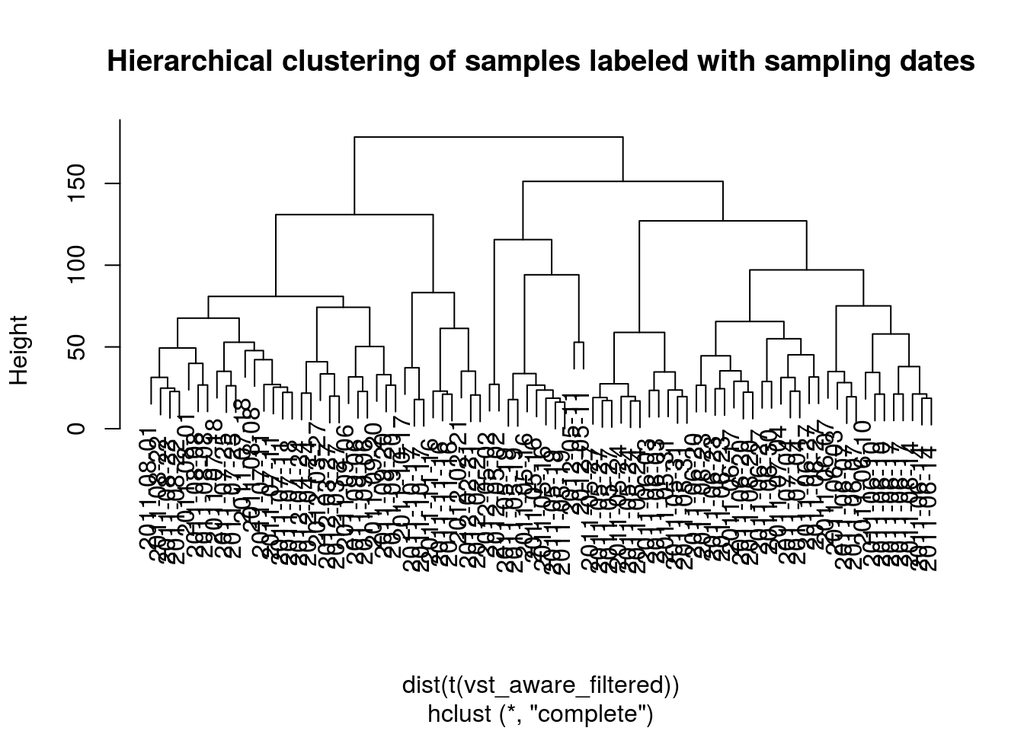

```r
hc <- hclust(dist(t(vst_aware_filtered)))
plot(hc, main = "Hierarchical clustering of samples labeled with sampling dates")
```

# 4 Identification of season periods between clustered samples

Cut the tree in different clusters

```r
ct <- cutree(hc, h = 70)
```

Reassignment of season number identifiers for each samples.

Because there are more samples of May and June (half of the samples), the first ramifications and clusters in the trees are between samples of these months.

To avoid that, we merge the ramifications for these months and focus on the clusters between seasons.

```r
ct[ct ==1 | ct == 2 | ct ==3 | ct ==4 | ct ==5 | ct ==11 | ct == 12] <- 1 # 05-06 = early-summer
ct[ct == 6] <- 2 # 07-08 = late-summer
ct[ct == 7] <- 3 # 09 = autumn
ct[ct == 8 | ct == 9] <- 4 # 10-02 = winter
ct[ct ==10] <- 5 # 03-04 == spring
```

Rename clusters with seasons’names

```r
tp <- factor(ct,labels=c("early-summer","late-summer","autumn","winter","spring"))
tp_char <- as.character(tp)
tp_char_ordered <- tp_char[hc$order]
```

Change labels in the dendrogram

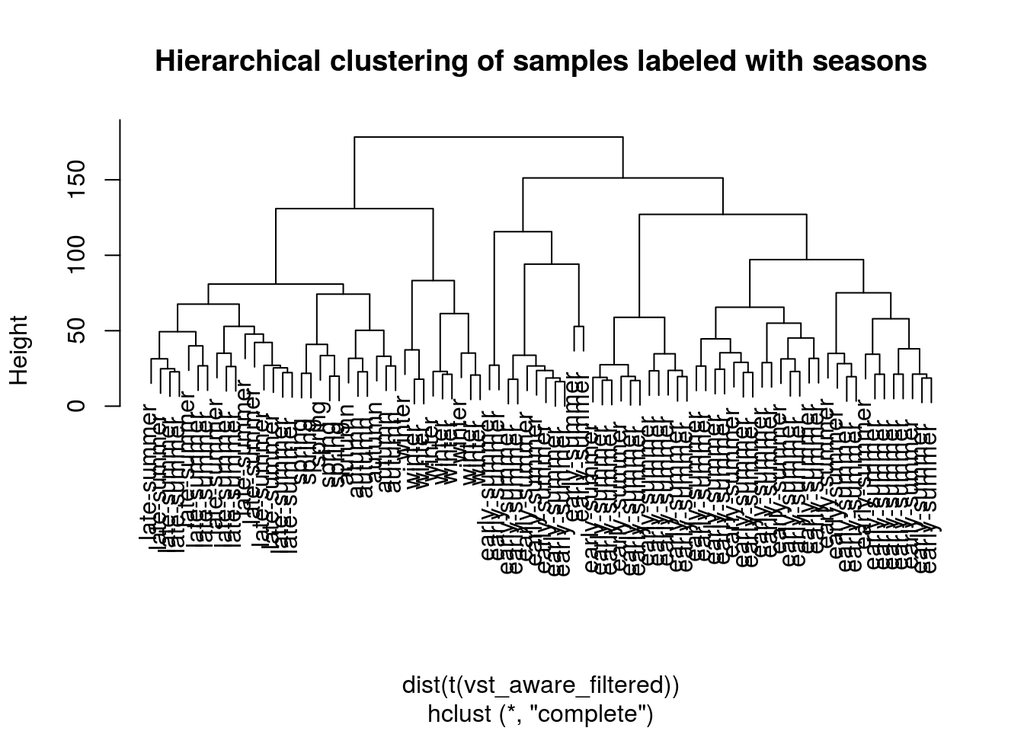

```r
labels(hc) <- tp_char_ordered
plot(hc, main="Hierarchical clustering of samples labeled with seasons")
```

# 5 Season expression specificity for all genes

## 5.1 Compute season expression specificity

```r
es <- expressionSpecificity(vst_aware_filtered, tp_char, mode = "local", output="complete")
```

```
## Calculating tissue specificity
```

This expressionSpecificity function calculates the season expression specificity score. The score ranges from 0 to 1 i.e. from ubiquitous to season specific

The expressionSpecificity function takes as argument an expression matrix, a factor containing the corresponding season for every sample,and two options:

“local” mode which computes season specificity, and “global mode” which computes sample specificity.

“complete mode” returns the specificity scores for every genes, plus the average expression of a gene in each season, the maximal average expression of a gene in a season and the number of seasons taken into account for calculation where the gene expresion is higher than 0.

In short, this function will split the samples by seasons and compute the average expression of every gene (aij) in every seaon. Then, it will compute the maximal average expression in a season for every gene (max(ai in 1:n)). Finally, it will calculate the score by dividing average expression in every season by the maximal average expression in a season, summing all the seasons, and then dividing by the number of season.

## 5.2 Plot gene specificity score distribution of all genes

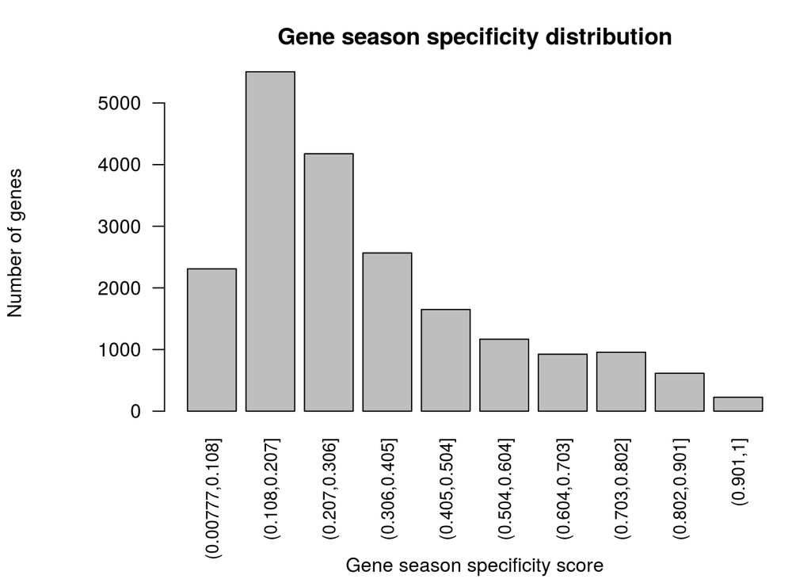

```r
par(mar = c(7.1, 7.1, 3.1, 1.1), mgp = c(6, 1, 0))
# plot margin: mar=c(bottom,left,top,right)
# axis margin: mgp=c(axis title, axis labels, axis line)
barplot(table(cut(es[,"score"],10)),las=2,main="Gene season specificity distribution",
        ylab = "Number of genes", xlab = "Gene season specificity score", cex.names = 0.9)
```

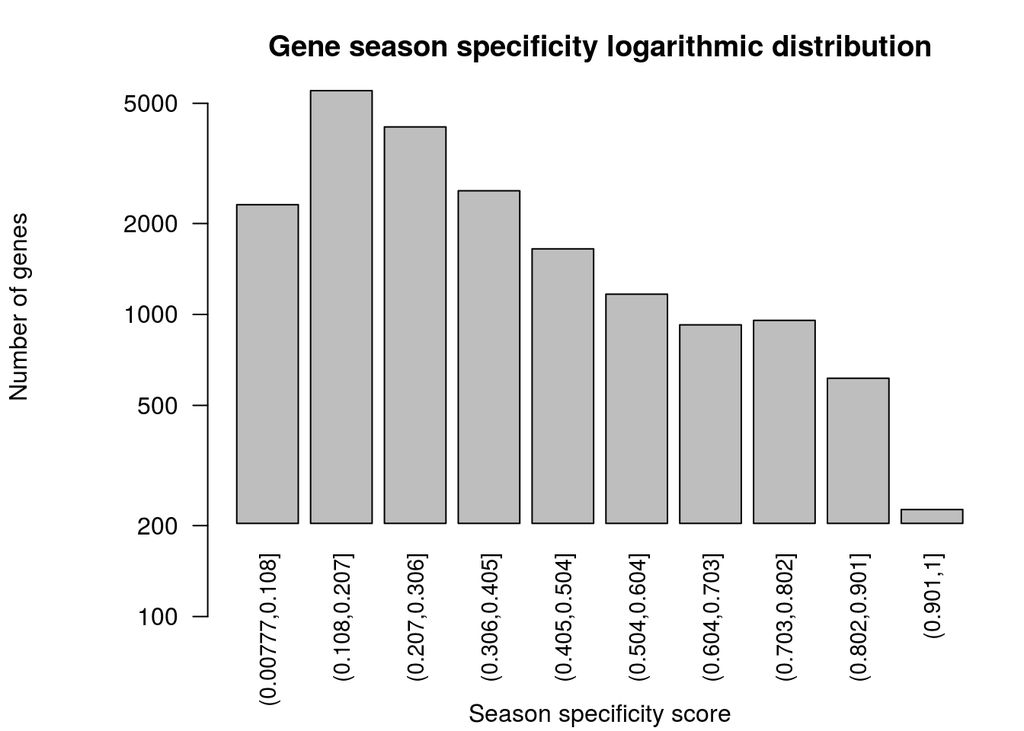

```r
barplot(table(cut(es[,"score"],10)),las=2,main="Gene season specificity logarithmic distribution",log="y", ylab = "Number of genes", xlab = "Season specificity score", cex.names = 0.9)
```

```r
# "cut" function splits gene season specificity score values into ten levels or bins.
# Then table represents in a bar plot the number of genes that have this level of season specificity.
```

We observed that most of the genes have low or average score, which means that are very ubiquitous. Only a very small fraction of them are season specific (score between 0.9 and 1), around 200 genes.

## Boxplot gene expression for each gene season specificity score category

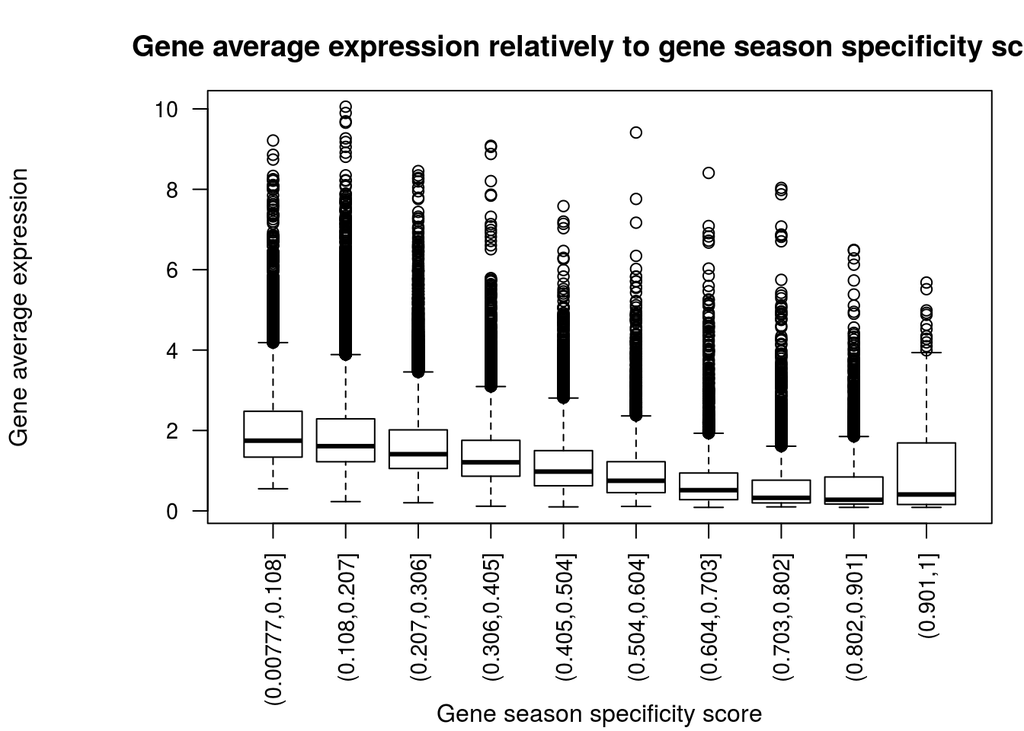

```r
par(mar = c(7.1, 7.1, 3.1, 1.1), mgp = c(6, 1, 0))
boxplot(split(es[,2:6],cut(es[,"score"],10)),las=2, main= "Gene average expression relatively to gene season specificity score",
        ylab = "Gene average expression", xlab = "Gene season specificity score",cex.axis=0.9)
```

```r
# "es[,2:6]" is the average expression in individual seasons: autumn, early-summer, late-summer, spring, winter.
# Then it splits genes'average expression in individual seasons relatively to gene's specificity score level organised in 10 bins.
# Finally, it plots genes'average expression for every genes'season specificity score level.
```

Interestingly the genes with less season specificity (ie the most ubiquitous) are the most expressed.

## 5.3 Check how many genes are never expressed in a season

```r
pander(round(colSums(is.na(es[,2:6])) / nrow(es) * 100,2))
```

| autumn | early-summer | late-summer | spring | winter |
| --- | --- | --- | --- | --- |
| 3.96 | 0 | 1.24 | 2.81 | 3.47 |

```r
# "colSums(is.na(es[,2:6])" counts all the non expressed genes in a season (their average expression value is listed as na).
# The number of non expressed genes is then divided by the number of genes and multiplied by 100 to calculate the percentage.
```

Less than 5% of the genes are never expressed in any season. Interestingly all of the genes are expressed during early summer. Either this could imply that all genes are necessary at that time of the year in a very active metabolism, or either it could be a sampling biais as half of the samples were sampled in that time of the year.

## 5.4 Check for genes more expressed during a season

For every season, select genes whose average expression in a season is equal to the maximal average expression across all seasons. This list of genes obtained corresponds to the genes with an expression peak in the season tested. It also plots gene season specificity distribution per season.

```
## There are 7049 genes with an expression peak in early-summer
```

```
## There are 2567 genes with an expression peak in late-summer
```

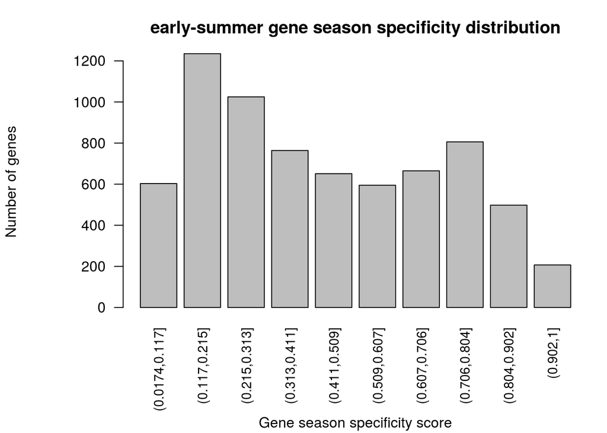

```
## There are 1613 genes with an expression peak in autumn
```

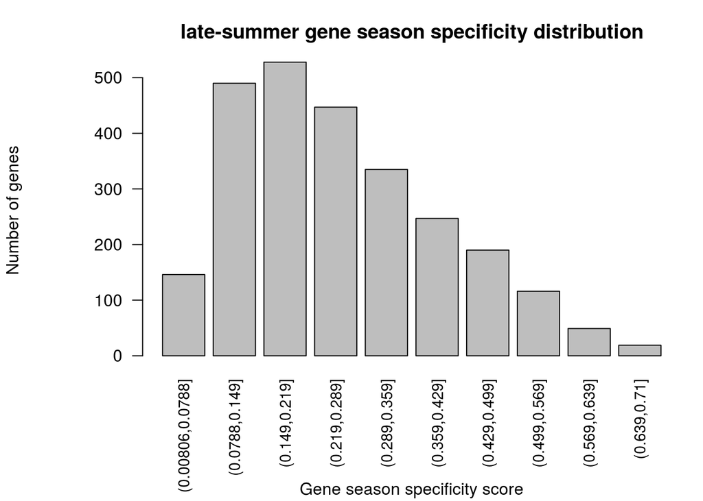

```
## There are 5694 genes with an expression peak in winter
```

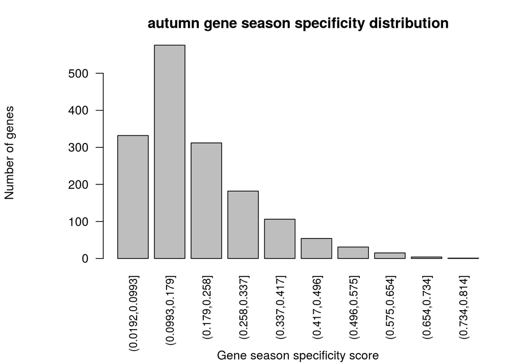

```
## There are 3173 genes with an expression peak in spring
```

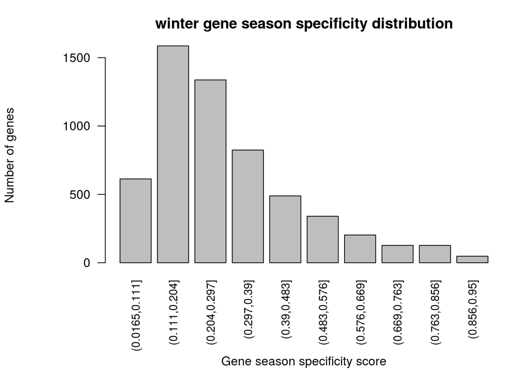

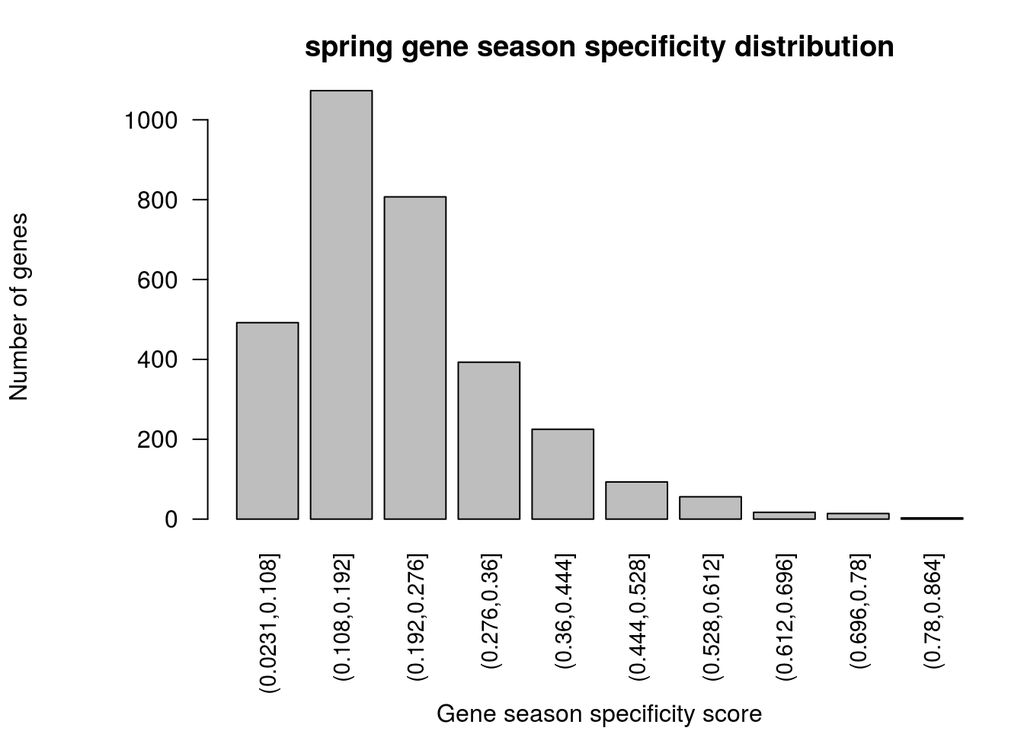

```r
dev.null <- sapply(levels(tp),function(x){
  sel <- es[,x] == es[,"maxn"]
  message(sprintf("There are %s genes with an expression peak in %s",
                  sum(sel,na.rm=TRUE),x))
  par(mar = c(7.1, 7.1, 3.1, 1.1), mgp = c(6, 1, 0))
  barplot(table(cut(es[sel,"score"],10)),las=2,
          main=paste0(x," gene season specificity distribution"),
          ylab= "Number of genes", xlab= "Gene season specificity score", cex.names = 0.9)
})
```

## 5.5 Get lists of genes more expressed during a season

```r
season_list <- sapply(levels(tp), function(x){
  sel <- es[,x] == es[,"maxn"]
  sel <- sel[!is.na(sel)]
  gene_list <- names(sel[sel==TRUE])
  return(gene_list)
})
```

The lists of season specific genes are too large. There is a need for a threshold to focus only of the most season specific genes with the highest scores.

Save season specific lists of genes

```r
dir.create(file.path("analysis","season"),showWarnings = FALSE)
dev.null <- sapply(levels(tp), function(x){
  write(season_list[[x]],file = paste0("analysis/season/",x,"_peak_genes"))
})
```

## 5.6 Get lists of genes more expressed during a season with high specificity

Get the names of genes that are more expressed in a season than in the other, and whose score is above a threshold specificity score of 0.6.

```r
season_specific_genes <- sapply(levels(tp), function(x){
  x.genes <- names(which(es[es[,x] == es[,"maxn"],"score"]>0.6))
  message(sprintf("There are %s genes that are %s specific",length(x.genes),x))
  return(x.genes)
})
```

```
## There are 2232 genes that are early-summer specific
```

```
## There are 35 genes that are late-summer specific
```

```
## There are 16 genes that are autumn specific
```

```
## There are 442 genes that are winter specific
```

```
## There are 39 genes that are spring specific
```

Save season specific lists of genes

```r
dev.null <- sapply(levels(tp), function(x){
  write(season_specific_genes[[x]],file = paste0("analysis/season/",x,"_specific_genes"))
})
```

# 6 Redo season specificity analysis for photosynthetic goi

Read Gene Of Interest csv file

```r
goi <- read.csv("~/Git/UPSCb/projects/spruce-needles/doc/GOI_list.csv", header = FALSE)
```

Select counts only for those genes

```r
sel <- vst_aware_filtered[rownames(vst_aware_filtered) %in% goi$V1,]
```

## 6.1 Compute season expression specificity

```r
es <- expressionSpecificity(sel, tp_char, mode = "local", output="complete")
```

```
## Calculating tissue specificity
```

## 6.2 Plot gene specificity score distribution of all genes

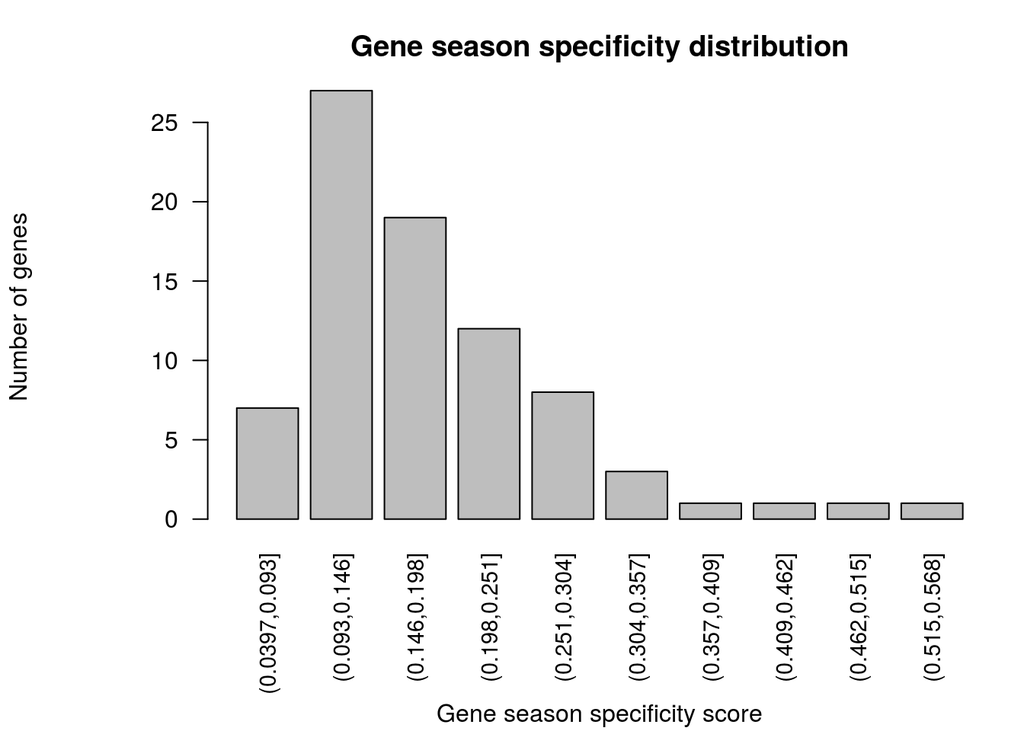

```r
par(mar = c(7.1, 7.1, 3.1, 1.1), mgp = c(6, 1, 0))
# plot margin: mar=c(bottom,left,top,right)
# axis margin: mgp=c(axis title, axis labels, axis line)
barplot(table(cut(es[,"score"],10)),las=2,main="Gene season specificity distribution",
        ylab = "Number of genes", xlab = "Gene season specificity score", cex.names = 0.9)
```

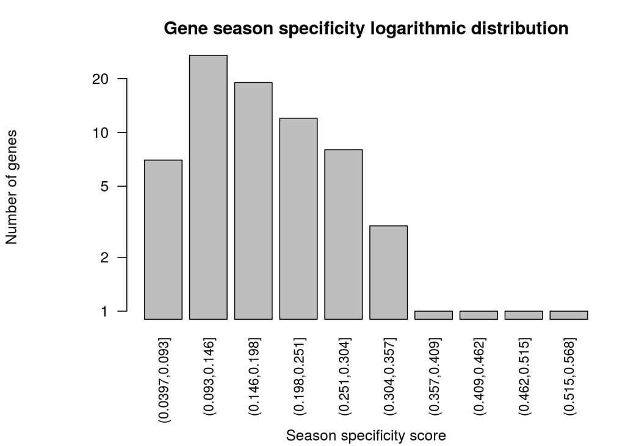

```r
barplot(table(cut(es[,"score"],10)),las=2,main="Gene season specificity logarithmic distribution",log="y", ylab = "Number of genes", xlab = "Season specificity score", cex.names = 0.9)
```

```r
# "cut" function splits gene season specificity score values into ten levels or bins.
# Then table represents in a bar plot the number of genes that have this level of season specificity.
```

## Boxplot gene expression for each gene season specificity score category

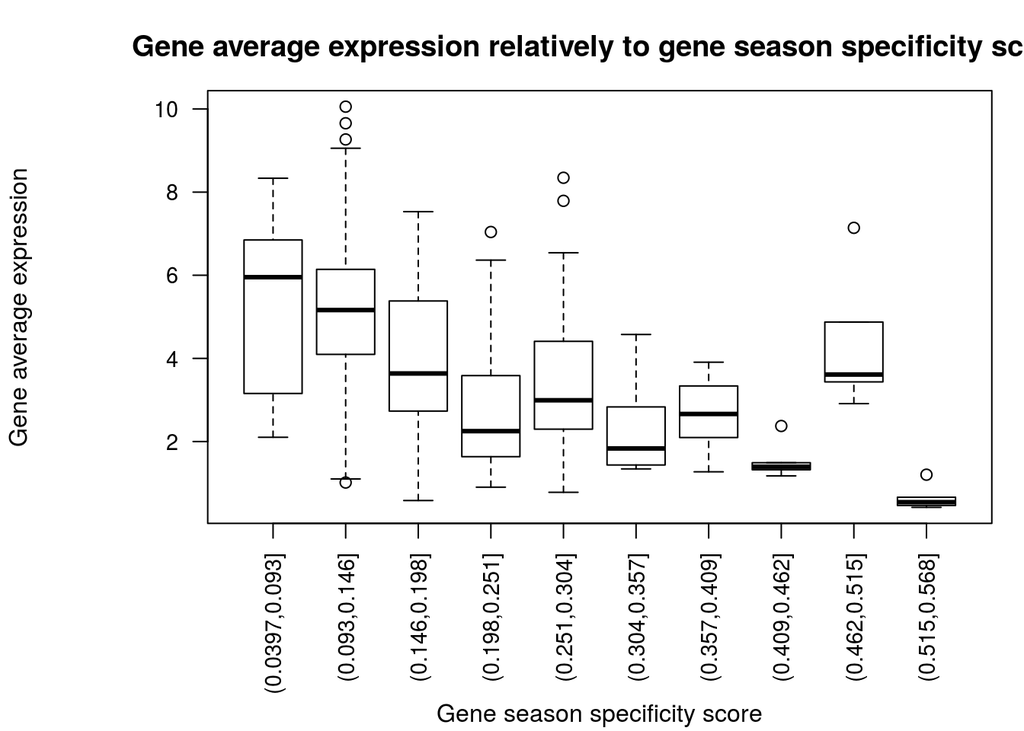

```r
par(mar = c(7.1, 7.1, 3.1, 1.1), mgp = c(6, 1, 0))
boxplot(split(es[,2:6],cut(es[,"score"],10)),las=2, main= "Gene average expression relatively to gene season specificity score",
        ylab = "Gene average expression", xlab = "Gene season specificity score",cex.axis=0.9)
```

```r
# "es[,2:6]" is the average expression in individual seasons: autumn, early-summer, late-summer, spring, winter.
# Then it splits genes'average expression in individual seasons relatively to gene's specificity score level organised in 10 bins.
# Finally, it plots genes'average expression for every genes'season specificity score level.
```

Interestingly the genes with less season specificity (ie the most ubiquitous) are the most expressed.

## 6.3 Check how many genes are never expressed in a season

```r
pander(round(colSums(is.na(es[,2:6])) / nrow(es) * 100,2))
```

| autumn | early-summer | late-summer | spring | winter |
| --- | --- | --- | --- | --- |
| 0 | 0 | 0 | 0 | 0 |

```r
# "colSums(is.na(es[,2:6])" counts all the non expressed genes in a season (their average expression value is listed as na).
# The number of non expressed genes is then divided by the number of genes and multiplied by 100 to calculate the percentage.
```

Less than 5% of the genes are never expressed in any season. Interestingly all of the genes are expressed during early summer. Either this could imply that all genes are necessary at that time of the year in a very active metabolism, or either it could be a sampling biais as half of the samples were sampled in that time of the year.

## 6.4 Check for genes more expressed during a season

```r
dev.null <- sapply(levels(tp),function(x){
  sel <- es[,x] == es[,"maxn"]
  message(sprintf("There are %s genes with an expression peak in %s",
                  sum(sel,na.rm=TRUE),x))
})
```

```
## There are 7 genes with an expression peak in early-summer
```

```
## There are 34 genes with an expression peak in late-summer
```

```
## There are 9 genes with an expression peak in autumn
```

```
## There are 12 genes with an expression peak in winter
```

```
## There are 18 genes with an expression peak in spring
```

There are 7 genes with an expression peak in early-summer There are 34 genes with an expression peak in late-summer There are 9 genes with an expression peak in autumn There are 12 genes with an expression peak in winter There are 18 genes with an expression peak in spring

It could be interesting to look at the photosynthetic genes that are more expressed in Autumn and Winter.

## 6.5 Get lists of genes more expressed during a season

```r
season_list <- sapply(levels(tp), function(x){
  sel <- es[,x] == es[,"maxn"]
  sel <- sel[!is.na(sel)]
  gene_list <- names(sel[sel==TRUE])
  return(gene_list)
})
```

The lists of season specific genes are too large. There is a need for a threshold to focus only of the most season specific genes with the highest scores.

Save season specific lists of genes

```r
dir.create(file.path("analysis/season/", "photosynthetic_goi"))
dev.null <- sapply(levels(tp), function(x){
  write(season_list[[x]],file = paste0("analysis/season/photosynthetic_goi/",x,"_peak_genes"))
})
```

## 6.6 Get lists of genes more expressed during a season with high specificity

```r
season_specific_genes <- sapply(levels(tp), function(x){
  x.genes <- names(which(es[es[,x] == es[,"maxn"],"score"]>0.6))
  message(sprintf("There are %s genes that are %s specific",length(x.genes),x))
  return(x.genes)
})
```

```
## There are 0 genes that are early-summer specific
```

```
## There are 0 genes that are late-summer specific
```

```
## There are 0 genes that are autumn specific
```

```
## There are 0 genes that are winter specific
```

```
## There are 0 genes that are spring specific
```

There are 0 genes that are early-summer specific There are 0 genes that are late-summer specific There are 0 genes that are autumn specific There are 0 genes that are winter specific There are 0 genes that are spring specific No genes specific enough for a season to be above the threshold of specificity score

# 7 Redo season specificity analysis for cytoscape cluster 2,2 enriched in photosynthetic goi

Read Gene Of Interest csv file

```r
goi <- read.csv("~/Git/UPSCb/projects/spruce-needles/doc/cluster_goi_2,2_gene_list.csv", header = FALSE)
```

Select counts only for those genes

```r
sel <- vst_aware_filtered[rownames(vst_aware_filtered) %in% goi$V1,]
```

## 7.1 Compute season expression specificity

```r
es <- expressionSpecificity(sel, tp_char, mode = "local", output="complete")
```

```
## Calculating tissue specificity
```

## 7.2 Plot gene specificity score distribution of all genes

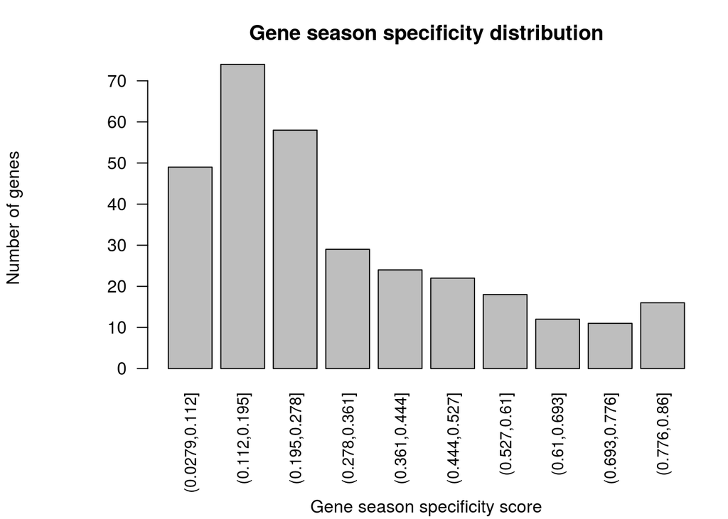

```r
par(mar = c(7.1, 7.1, 3.1, 1.1), mgp = c(6, 1, 0))
# plot margin: mar=c(bottom,left,top,right)
# axis margin: mgp=c(axis title, axis labels, axis line)
barplot(table(cut(es[,"score"],10)),las=2,main="Gene season specificity distribution",
        ylab = "Number of genes", xlab = "Gene season specificity score", cex.names = 0.9)
```

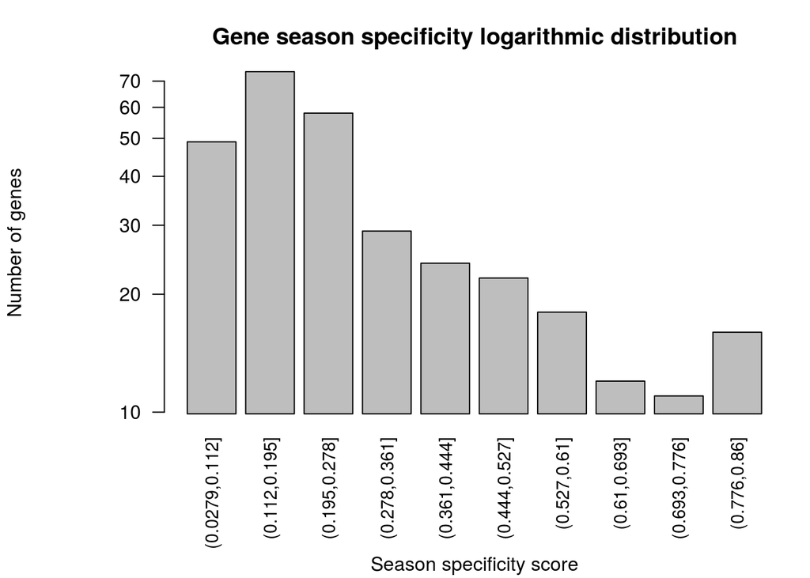

```r
barplot(table(cut(es[,"score"],10)),las=2,main="Gene season specificity logarithmic distribution",log="y", ylab = "Number of genes", xlab = "Season specificity score", cex.names = 0.9)
```

```r
# "cut" function splits gene season specificity score values into ten levels or bins.
# Then table represents in a bar plot the number of genes that have this level of season specificity.
```

## Boxplot gene expression for each gene season specificity score category

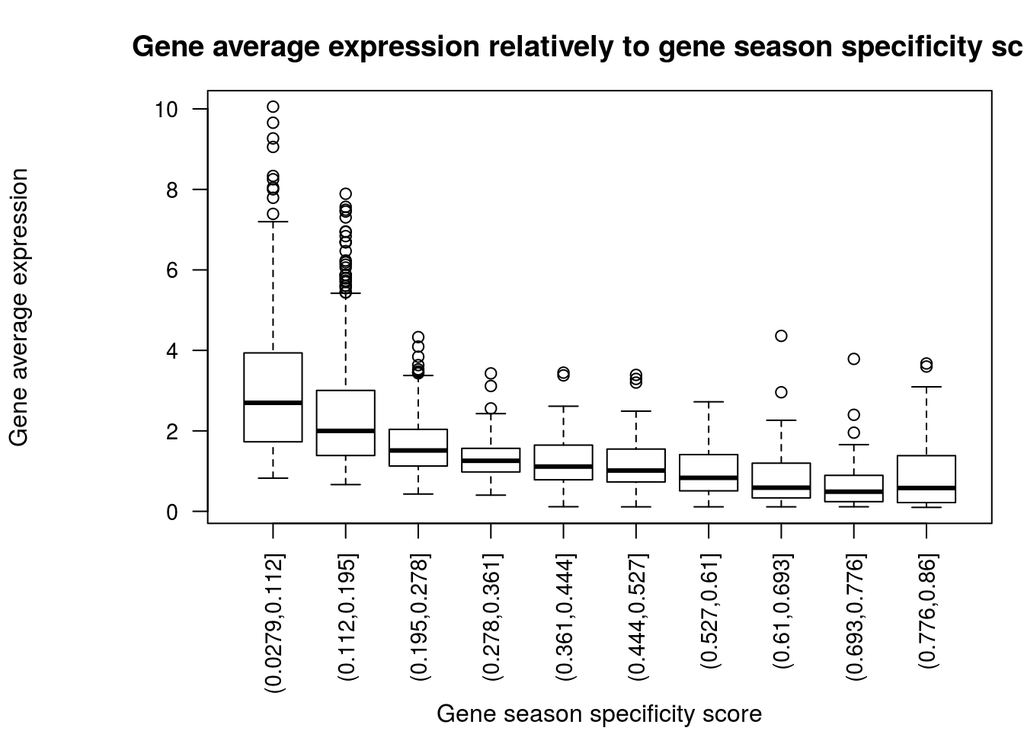

```r
par(mar = c(7.1, 7.1, 3.1, 1.1), mgp = c(6, 1, 0))
boxplot(split(es[,2:6],cut(es[,"score"],10)),las=2, main= "Gene average expression relatively to gene season specificity score",
        ylab = "Gene average expression", xlab = "Gene season specificity score",cex.axis=0.9)
```

```r
# "es[,2:6]" is the average expression in individual seasons: autumn, early-summer, late-summer, spring, winter.
# Then it splits genes'average expression in individual seasons relatively to gene's specificity score level organised in 10 bins.
# Finally, it plots genes'average expression for every genes'season specificity score level.
```

Interestingly the genes with less season specificity (ie the most ubiquitous) are the most expressed.

## 7.3 Check how many genes are never expressed in a season

```r
pander(round(colSums(is.na(es[,2:6])) / nrow(es) * 100,2))
```

| autumn | early-summer | late-summer | spring | winter |
| --- | --- | --- | --- | --- |
| 30.67 | 0 | 0 | 32.27 | 3.19 |

```r
# "colSums(is.na(es[,2:6])" counts all the non expressed genes in a season (their average expression value is listed as na).
# The number of non expressed genes is then divided by the number of genes and multiplied by 100 to calculate the percentage.
```

30% of the genes are never expressed in autumn and spring. Those seasons are also the shorter one (composed of 1 or 2 months). Interestingly all of the genes are expressed during summer and almost all (96%) are expressed during winter. Those seasons are also the longer ones (composed of 4 or 5 months). This could be a biais introduced by the length of the seasons choosed subjectively by looking at how the samples at different times of the year cluster together in term of genes expression.

## 7.4 Check for genes more expressed during a season

```r
dev.null <- sapply(levels(tp),function(x){
  sel <- es[,x] == es[,"maxn"]
  message(sprintf("There are %s genes with an expression peak in %s",
                  sum(sel,na.rm=TRUE),x))
})
```

```
## There are 152 genes with an expression peak in early-summer
```

```
## There are 75 genes with an expression peak in late-summer
```

```
## There are 13 genes with an expression peak in autumn
```

```
## There are 59 genes with an expression peak in winter
```

```
## There are 14 genes with an expression peak in spring
```

There are 152 genes with an expression peak in early-summer There are 75 genes with an expression peak in late-summer There are 13 genes with an expression peak in autumn There are 59 genes with an expression peak in winter There are 14 genes with an expression peak in spring

It could be interesting to look at the photosynthetic genes that are more expressed in Autumn and Winter.

## 7.5 Get lists of genes more expressed during a season

```r
season_list <- sapply(levels(tp), function(x){
  sel <- es[,x] == es[,"maxn"]
  sel <- sel[!is.na(sel)]
  gene_list <- names(sel[sel==TRUE])
  return(gene_list)
})
```

Save season specific lists of genes

```r
dir.create(file.path("analysis/season/", "cytoscape_cluster_photosynthetic_genes_enriched_1"))
dev.null <- sapply(levels(tp), function(x){
  write(season_list[[x]],file = paste0("analysis/season/cytoscape_cluster_photosynthetic_genes_enriched_1/",x,"_peak_genes"))
})
```

The lists of season specific genes are too large. There is a need for a threshold to focus only of the most season specific genes with the highest scores.

## 7.6 Get lists of genes more expressed during a season with high specificity

Get the names of genes that are more expressed in a season than in the other, and whose score is above a threshold specificity score of 0.6.

```r
season_specific_genes <- sapply(levels(tp), function(x){
  x.genes <- names(which(es[es[,x] == es[,"maxn"],"score"]>0.6))
  message(sprintf("There are %s genes that are %s specific",length(x.genes),x))
  return(x.genes)
})
```

```
## There are 35 genes that are early-summer specific
```

```
## There are 2 genes that are late-summer specific
```

```
## There are 0 genes that are autumn specific
```

```
## There are 5 genes that are winter specific
```

```
## There are 0 genes that are spring specific
```

There are 35 genes that are early-summer specific There are 2 genes that are late-summer specific There are 0 genes that are autumn specific There are 5 genes that are winter specific There are 0 genes that are spring specific

It could be interesting to look at the five photosynthetic genes highly specific for winter Save season specific lists of genes

```r
dev.null <- sapply(levels(tp), function(x){
  write(season_specific_genes[[x]],file = paste0("analysis/season/cytoscape_cluster_photosynthetic_genes_enriched_1/",x,"_specific_genes"))
})
```

# 8 Redo season specificity analysis for cytoscape cluster 2,4 enriched in photosynthetic goi

Read Gene Of Interest csv file

```r
goi <- read.csv("~/Git/UPSCb/projects/spruce-needles/doc/cluster_goi_2,4_gene_list.csv", header = FALSE)
```

Select counts only for those genes

```r
sel <- vst_aware_filtered[rownames(vst_aware_filtered) %in% goi$V1,]
```

## 8.1 Compute season expression specificity

```r
es <- expressionSpecificity(sel, tp_char, mode = "local", output="complete")
```

```
## Calculating tissue specificity
```

## 8.2 Plot gene specificity score distribution of all genes

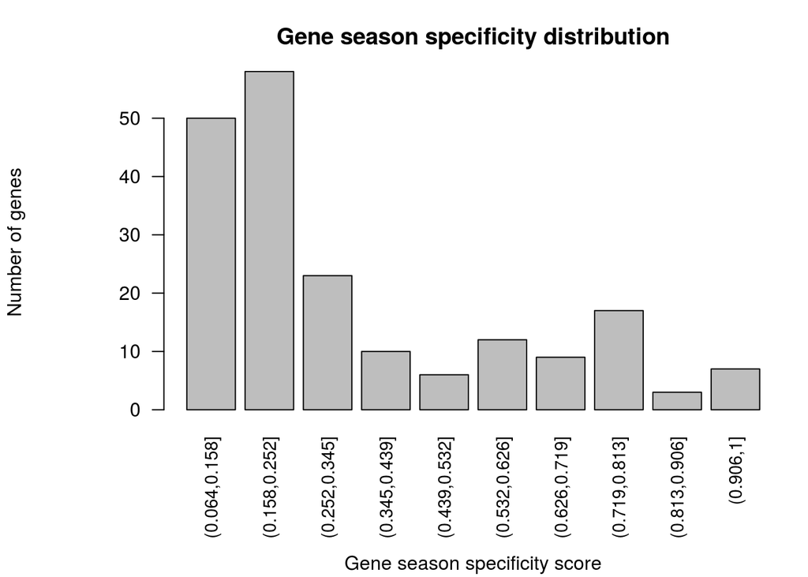

```r
par(mar = c(7.1, 7.1, 3.1, 1.1), mgp = c(6, 1, 0))
# plot margin: mar=c(bottom,left,top,right)
# axis margin: mgp=c(axis title, axis labels, axis line)
barplot(table(cut(es[,"score"],10)),las=2,main="Gene season specificity distribution",
        ylab = "Number of genes", xlab = "Gene season specificity score", cex.names = 0.9)
```

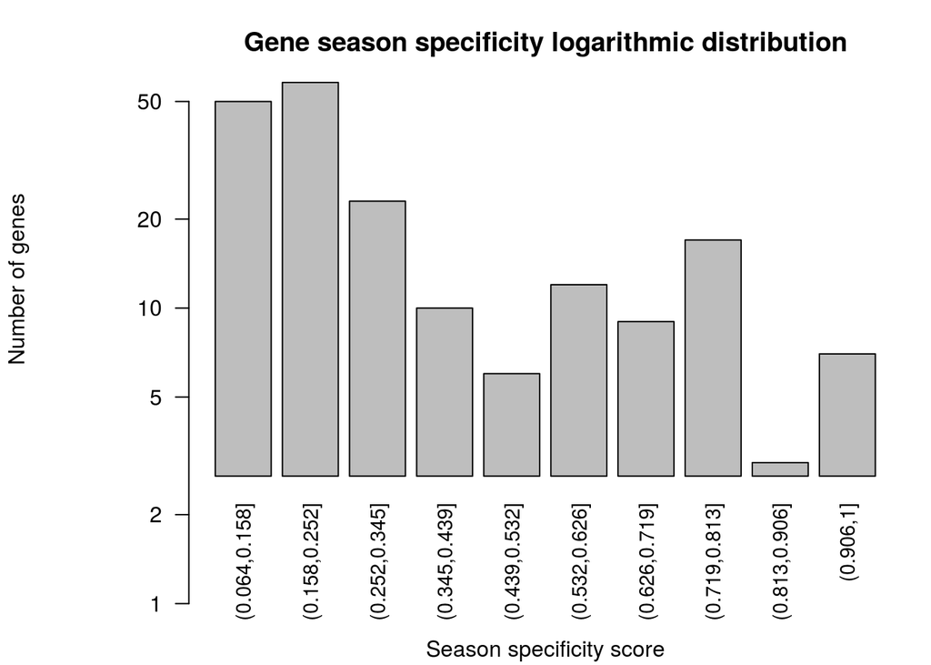

```r
barplot(table(cut(es[,"score"],10)),las=2,main="Gene season specificity logarithmic distribution",log="y", ylab = "Number of genes", xlab = "Season specificity score", cex.names = 0.9)
```

```r
# "cut" function splits gene season specificity score values into ten levels or bins.
# Then table represents in a bar plot the number of genes that have this level of season specificity.
```

## Boxplot gene expression for each gene season specificity score category

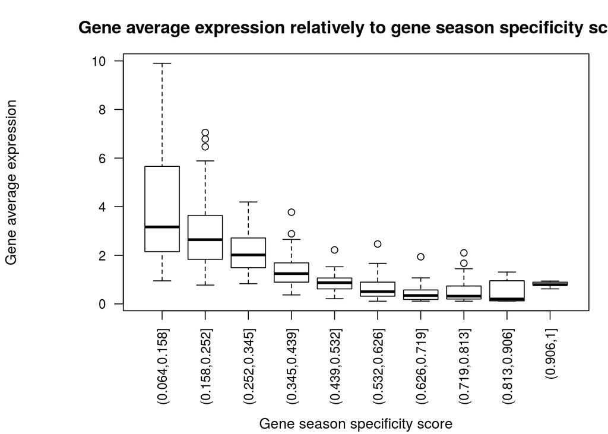

```r
par(mar = c(7.1, 7.1, 3.1, 1.1), mgp = c(6, 1, 0))
boxplot(split(es[,2:6],cut(es[,"score"],10)),las=2, main= "Gene average expression relatively to gene season specificity score",
        ylab = "Gene average expression", xlab = "Gene season specificity score",cex.axis=0.9)
```

```r
# "es[,2:6]" is the average expression in individual seasons: autumn, early-summer, late-summer, spring, winter.
# Then it splits genes'average expression in individual seasons relatively to gene's specificity score level organised in 10 bins.
# Finally, it plots genes'average expression for every genes'season specificity score level.
```

Interestingly the genes with less season specificity (ie the most ubiquitous) are the most expressed.

## 8.3 Check how many genes are never expressed in a season

```r
pander(round(colSums(is.na(es[,2:6])) / nrow(es) * 100,2))
```

| autumn | early-summer | late-summer | spring | winter |
| --- | --- | --- | --- | --- |
| 14.36 | 0 | 12.31 | 3.59 | 10.26 |

```r
# "colSums(is.na(es[,2:6])" counts all the non expressed genes in a season (their average expression value is listed as na).
# The number of non expressed genes is then divided by the number of genes and multiplied by 100 to calculate the percentage.
```

between 10 and 15% of those genes are never expressed in autumn late summer and winter. Still quite low, not very significative.

## 8.4 Check for genes more expressed during a season

```r
dev.null <- sapply(levels(tp),function(x){
  sel <- es[,x] == es[,"maxn"]
  message(sprintf("There are %s genes with an expression peak in %s",
                  sum(sel,na.rm=TRUE),x))
})
```

```
## There are 65 genes with an expression peak in early-summer
```

```
## There are 50 genes with an expression peak in late-summer
```

```
## There are 25 genes with an expression peak in autumn
```

```
## There are 17 genes with an expression peak in winter
```

```
## There are 38 genes with an expression peak in spring
```

Specificity results for cytoscape cluster enriched in photosynthetic genes 2,2: There are 152 genes with an expression peak in early-summer There are 75 genes with an expression peak in late-summer There are 13 genes with an expression peak in autumn There are 59 genes with an expression peak in winter There are 14 genes with an expression peak in spring

Specificity results for cytoscape cluster enriched in photosynthetic genes 2,4: There are 65 genes with an expression peak in early-summer There are 50 genes with an expression peak in late-summer There are 25 genes with an expression peak in autumn There are 17 genes with an expression peak in winter There are 38 genes with an expression peak in spring

Interestingly, cluster 2,4 has more genes specific for Autumn and less for winter than cluster 2,2 It could also be interesting to look at the photosynthetic genes that are more expressed in Autumn and Winter.

## 8.5 Get lists of genes more expressed during a season

```r
season_list <- sapply(levels(tp), function(x){
  sel <- es[,x] == es[,"maxn"]
  sel <- sel[!is.na(sel)]
  gene_list <- names(sel[sel==TRUE])
  return(gene_list)
})
```

Save season specific lists of genes

```r
dir.create(file.path("analysis/season/", "cytoscape_cluster_photosynthetic_genes_enriched_2"))
dev.null <- sapply(levels(tp), function(x){
  write(season_list[[x]],file = paste0("analysis/season/cytoscape_cluster_photosynthetic_genes_enriched_2/",x,"_peak_genes"))
})
```

The lists of season specific genes are too large. There is a need for a threshold to focus only of the most season specific genes with the highest scores.

## 8.6 Get lists of genes more expressed during a season with high specificity

Get the names of genes that are more expressed in a season than in the other, and whose score is above a threshold specificity score of 0.6.

```r
season_specific_genes <- sapply(levels(tp), function(x){
  x.genes <- names(which(es[es[,x] == es[,"maxn"],"score"]>0.6))
  message(sprintf("There are %s genes that are %s specific",length(x.genes),x))
  return(x.genes)
})
```

```
## There are 40 genes that are early-summer specific
```

```
## There are 0 genes that are late-summer specific
```

```
## There are 0 genes that are autumn specific
```

```
## There are 0 genes that are winter specific
```

```
## There are 0 genes that are spring specific
```

High specificity results for cytoscape cluster enriched in photosynthetic genes 2,2: There are 35 genes that are early-summer specific There are 2 genes that are late-summer specific There are 0 genes that are autumn specific There are 5 genes that are winter specific There are 0 genes that are spring specific

High specificity results for cytoscape cluster enriched in photosynthetic genes 2,4: There are 40 genes that are early-summer specific There are 0 genes that are late-summer specific There are 0 genes that are autumn specific There are 0 genes that are winter specific There are 0 genes that are spring specific

There are no genes highly specific for Autumn or Winter in cluster 2,4 The threshold could be to high for such a short list of genes Example of venn diagram

```r
# ## Overlap
# plot.new()
#grid.draw(venn.diagram(list(Phloem=phloem.winter.genes,
                       #      Xylem=xylem.winter.genes),
                       # filename = NULL,fill=pal[1:2],alpha=0.6))
                       #
# ### Phloem specific
# write(setdiff(phloem.winter.genes,xylem.winter.genes),file="analysis/season/phloem-only.winter.genes")
#
# ### Xylem specific
# write(setdiff(xylem.winter.genes,phloem.winter.genes),file="analysis/season/xylem-only.winter.genes")
#
# ### Common
#write(intersect(phloem.winter.genes,xylem.winter.genes),file="analysis/season/phloem-xylem.winter.genes")
```